# Wind data in R - Review of a peeled potato

Johannes Misensky

2023-01-22

## Einleitung

Dieses Paper behandelt ein kritisches Review des R-Blog Artikels: “Wind data in R, part I: more than one way to peel a potato”. Quelle: [R-Wind](https://www.r-bloggers.com/2022/11/wind-data-in-r-part-i-more-than-one-way-to-peel-a-potato/)

Sämtliche aus dem Artikel entnommenen Aussagen werden mit dem Vermerkt [Quelle: R-Wind] gekennzeichnet.

Im Verlauf wird auf die folgenden Punkte eingegangen:

1. Sind Annahmen und im Artikel verwendete Begriffe bzw. Daten korrekt?
2. Gibt es eine Erklärung für die dargestellten Differenzen?

# Wind data in R, part I: more than one way to peel a potato - Zusammenfassung

Im Artikel werden zwei verschiedene Möglichkeiten nutzbare Windenergie zu berechnen gegenübergestellt. Der Autor nutzt dafür einerseits Daten von NASA POWER - einer Datenbank für weltweite meterologische Daten - und bReeze, ein r-package speziell für die Windkraftwerk berechnung entwickelt. [Quelle: R-Wind] Als Windkraftwerk wird das Model Enercon_E126_7 herangezogen.

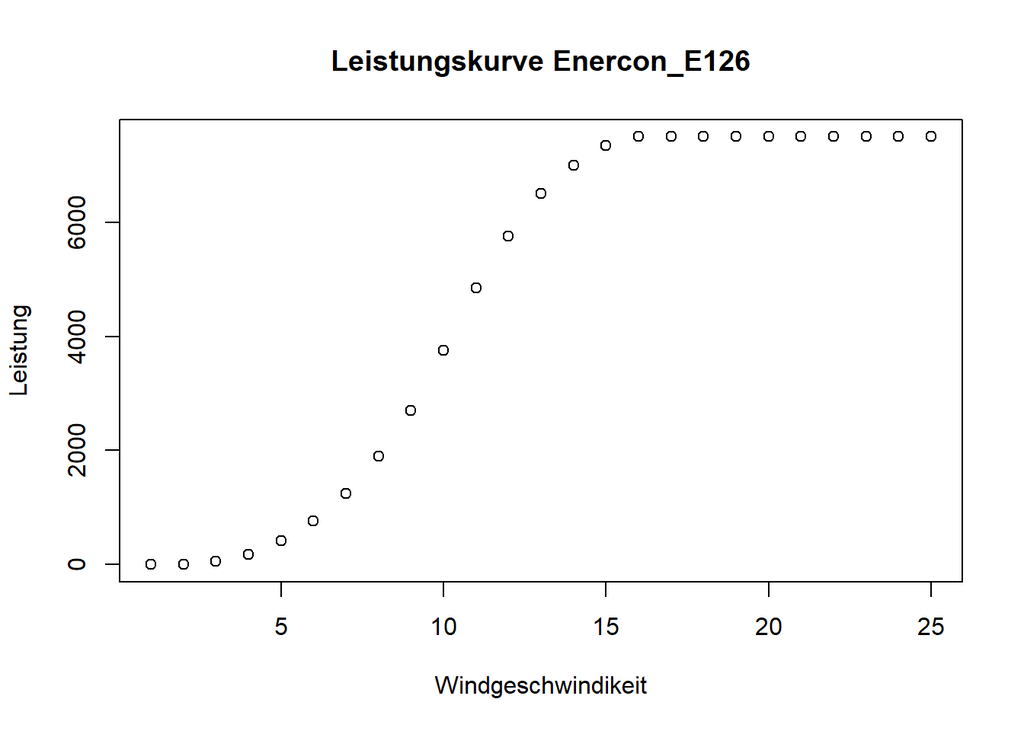

zur Berechnung der nutzbaren Windenergie schlägt der Autor folgende Funktion vor:

```r
calculate_wind_outputs <-function(windspeeds, measured_height, hub_height, power_curve, cutin_speed, cutout_speed, terrain)
{
  #First, we calculate what the wind speed would be at the hub height of the given turbine
  #We can use a simple linear adjustment and just increase the speeds by the correct amount

  if(terrain == "onshore")
  {
    hellman_exponent = 1/7
  }

  else if(terrain == "offshore")
  {
    hellman_exponent = 1/9
  }
  adjustment_factor = (hub_height/measured_height)^hellman_exponent
  adjusted_wind_speeds = windspeeds*adjustment_factor

  #Let's create a vector which has the same length as the wind speeds
  power_output = adjusted_wind_speeds

  for(i in 1:length(power_output))
  {
    if(adjusted_wind_speeds[i] > cutin_speed & adjusted_wind_speeds[i] < cutout_speed)
    {
      for(j in 1:nrow(power_curve))
      {
        #Just make sure that this is working
        if(adjusted_wind_speeds[i] >= power_curve$speed[j] & adjusted_wind_speeds[i] < power_curve$speed[j+1])
        {
          #We want the power output to match the power curve so long as the wind speed is the same as or greater than
          # the power curve's predicting variable and below the one above
          power_output[i] = power_curve$power[j]
        }
      }
    }

    #You get no power output if your wind speed is either below the cut-in or above the cut-out speed
    else if(adjusted_wind_speeds[i] < cutin_speed | adjusted_wind_speeds[i] >= cutout_speed)
    {
      power_output[i] = 0
    }
  }


  #In keeping with good practice--a function should return only one variable
  return(power_output)
}
```

[Quelle: R-Wind]

die Funktion nimmt zwei Vereinfachungen an:

1. Der Wind weht in einer gegeben Zeiteinheit konstant
2. Die Berechnung der Windstärke an der Hubhöhe

Aus der NASA-DB werden Winddaten zwischen 2008-12-31 und 2010-01-01 entnommen

```
## NASA/POWER CERES/MERRA2 Native Resolution Hourly Data
##  Dates (month/day/year): 12/31/2008 through 01/01/2010
##  Location: Latitude  48.7716   Longitude 11.1422
##  Elevation from MERRA-2: Average for 0.5 x 0.625 degree lat/lon region = 449.8 meters
##  The value for missing source data that cannot be computed or is outside of the sources availability range: NA
##  Parameter(s):
##
##  Parameters:
##  WS10M     MERRA-2 Wind Speed at 10 Meters (m/s) ;
##  WS50M     MERRA-2 Wind Speed at 50 Meters (m/s)
##
## # A tibble: 6 × 8
##     LON   LAT  YEAR    MO    DY    HR WS10M WS50M
##   <dbl> <dbl> <dbl> <dbl> <dbl> <dbl> <dbl> <dbl>
## 1  11.1  48.8  2008    12    31     1  2.74  4.51
## 2  11.1  48.8  2008    12    31     2  2.93  3.66
## 3  11.1  48.8  2008    12    31     3  2.6   3.06
## 4  11.1  48.8  2008    12    31     4  2.66  3.13
## 5  11.1  48.8  2008    12    31     5  2.99  3.5
## 6  11.1  48.8  2008    12    31     6  3.24  3.84
```

[Quelle: R-Wind] Und anschließend ein “Capacity Faktor” berechnet.

```r
#As usual, we want to make sure we have a dataframe, which is the easiest way to work with this kind of thing in R
#The original data download is a tibble, with some metadata which we can discard here
hourly_wind_data = data.frame(hourly_wind_data)

#Put it through the works for the Enercon E-126
#I'm going to use the windspeeds from the 50m hub height, for fun
#Please note that as a decent member of the human race, I only use metric/SI units if at all possible
hourly_wind_energy = calculate_wind_outputs(windspeeds = hourly_wind_data$WS50M, measured_height = 50, hub_height = 135, cutin_speed = 3, cutout_speed = 25, power_curve = pow_curve_df, terrain = "onshore")
#What kind of capacity factor does this give us?
#Convert to MWh
#Then take into account that the total possible energy generated is 7.5 MW * 8760 hours in a year
capacity_factor_rough = 0.001*sum(hourly_wind_energy)/(7.5*8760)
```

[Quelle: R-Wind]

```
## [1] "Der Brechnete Kapazitätsfaktor beträgt: 0.17275395738204"
```

Für das bReeze Package wird eine ähnliche vorgangweise gewählt und ein Faktor rechnet:

```
## Pattern found: %d.%m.%Y %H:%M
```

```
##
##  Wind profile
##
##     alpha wind speed
##       [-]      [m/s]
## N     0.2      5.614
## NNE   0.2       3.89
## ENE   0.2      3.665
## E     0.2      2.707
## ESE   0.2      2.838
## SSE   0.2      2.538
## S     0.2      3.052
## SSW   0.2      5.042
## WSW   0.2       5.74
## W     0.2      3.406
## WNW   0.2       1.62
## NNW   0.2      2.673
## all   0.2      4.473
##
## reference height: 40 m
##
## call: windprofile(mast=mast_for_breeze, v.set=1, dir.set=1, num.sectors=12, method="fixed", alpha=c(0.2, 0.2, 0.2, 0.2, 0.2, 0.2, 0.2, 0.2, 0.2, 0.2, 0.2, 0.2), subset=NA, digits=3, print=TRUE)
```

```
##
##  Annual energy production
##
##       wind speed operation   total     0-5    5-10   10-15   15-20     >20
##            [m/s]     [h/a] [MWh/a] [MWh/a] [MWh/a] [MWh/a] [MWh/a] [MWh/a]
## N          7.156      2371    4774      92    1839    2390     431      22
## NNE        4.961       530     416      33     287      94       2
## ENE        4.674       271     204      16     127      58       3
## E          3.452       152      55       8      37      10
## ESE         3.62       165      80       8      46      23       2
## SSE        3.237       402     142      20      88      32       2
## S          3.892      1020     572      53     330     171      17       1
## SSW         6.43      1328    2357      53     677    1034     443     150
## WSW        7.321      1369    2995      51     836    1398     565     145
## W          4.345       548     401      28     215     138      18       1
## WNW        2.066       215      25       7      15       3
## NNW        3.409       390     181      18      98      56       8       1
## total      5.704      8760   12202     387    4595    5407    1491     320
##
## capacity factor: 0.186
##
## call: aep(profile=our_wind_profile, pc=pow_curve, hub.h=135, rho=1.225, avail=1, bins=c(0, 5, 10, 15, 20), sectoral=FALSE, digits=c(3, 0, 0, 3), print=TRUE)
```

```
## [1] "Der Brechnete Kapazitätsfaktor beträgt: 0.186"
```

[Quelle: R-Wind]

Wie sich zeigt gibt es einen Unterschied zwischen den beiden Berechnungen von 1%.

## 1. Sind Annahmen und verwendete Begriffe bzw. Daten korrekt?

Die in der Funktion calculate_wind_outputs vorgenommenen Annahmen werden korrekt dargestellt und werden in der Praxis ähnlich gehandhabt.

Der Begriff Kapazitätsfaktor wird korrekt verwendet. Wenn man die Formel

```
0.001*sum(hourly_wind_energy)/(7.5*8760)
```

betrachtet wird schnell klar das nicht hier der Wirkungsgrad (in englisch efficiency) errechnet wird.

Ein Kapazitätsfaktor einer Windkraftanlage ist ein Maß für die Auslastung einer Windkraftanlage. Er beschreibt die durchschnittliche Leistungsabgabe der Anlage über einen definierten Zeitraum im Verhältnis zu der maximal möglichen Leistungsabgabe der Anlage. Für die maximal mögliche Leistungsabgabe wird dabei unterstellt, dass die Anlage über den definierten Zeitraum mit der angegebenen Nennleistung der Windkraftanlage betrieben wird. Quelle: [Emargus](https://www.enargus.de/pub/bscw.cgi/d5621-2/*/*/Kapazit%c3%a4tsfaktor%20einer%20Windkraftanlage.html?op=Wiki.getwiki)

Anders ist es aber wenn man die verwendeten Daten näher betrachtet.

# In welchem Zeitraum werden die bReeze Winddaten bereitgestellt?

```
## [1] "Die zu Verfügung gestellten Daten beginnen zu folgendem Zeitpunkt: 06.05.2009 11:20"
```

```
## [1] "Und enden mit: 31.01.2010 23:50"
```

```r
date_1 = as.Date("2009-05-06")
date_2 = as.Date("2010-01-31")

diff_days = as.numeric(difftime(date_2,date_1, units = "days"))
print(paste0("Es werden: ",diff_days, " Tage erfasst"))
```

```
## [1] "Es werden: 270 Tage erfasst"
```

Wie bereits weiter oben erwähnt werden für die vorgestellte Funktion ein Zeitraum von 365 Tage herangezogen.

Hier ergibt sich also schon ein erster Unterschied da das Windpotentzial wahrscheinlich nicht gleichmäßig über das Jahr verteilt ist.

# Wie ist das Windpotenzial übers Jahr gesehen verteilt?

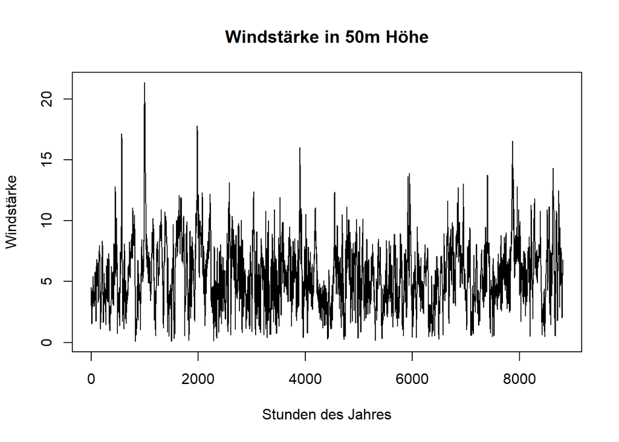

Vermutung: die windstärksten Monate liegen im ersten und letzten Quartal des Jahres

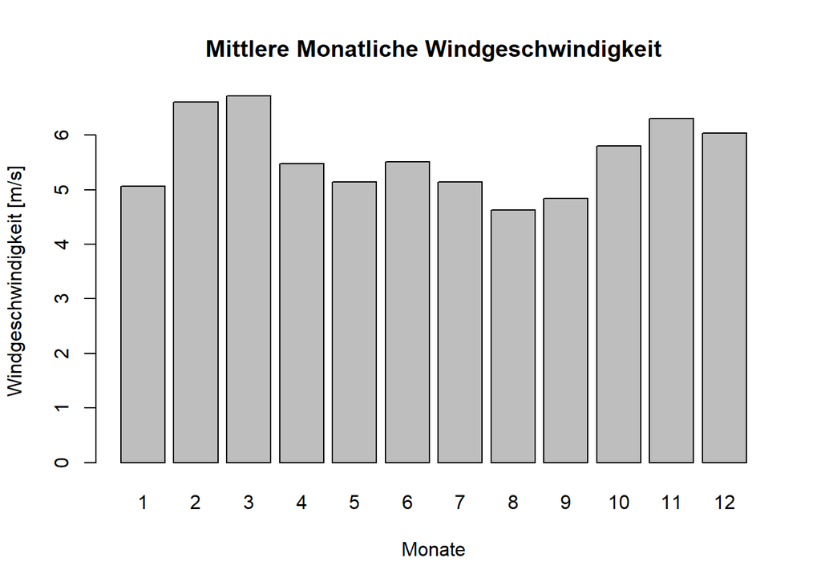

```r
# Erzeuge einenen Dataframe mit den Monatsmittelwerten
month_data = hourly_wind_data %>% group_by(MO) %>%
  summarise(Mean_month=mean(WS50M),
            .groups = 'drop') %>% as.data.frame()

#Plote einen Barplot mit den Monatsmittelwerten
data_bar = month_data$Mean_month
names(data_bar) = month_data$MO
barplot(data_bar, main = 'Mittlere Monatliche Windgeschwindigkeit',
        xlab = 'Monate', ylab = 'Windgeschwindigkeit [m/s]')
```

Die Vermutung scheint korrekt zu sein. Das ergibt folgendes Problem: der Dataframe “winddata” liefert 10 Minuten Daten im Zeitraum Mai (5) und 31. Jänner das heißt um den Kapazitätsfaktor korrekt zu vergleichen muss der gleiche Zeitraum herangezogen werden.

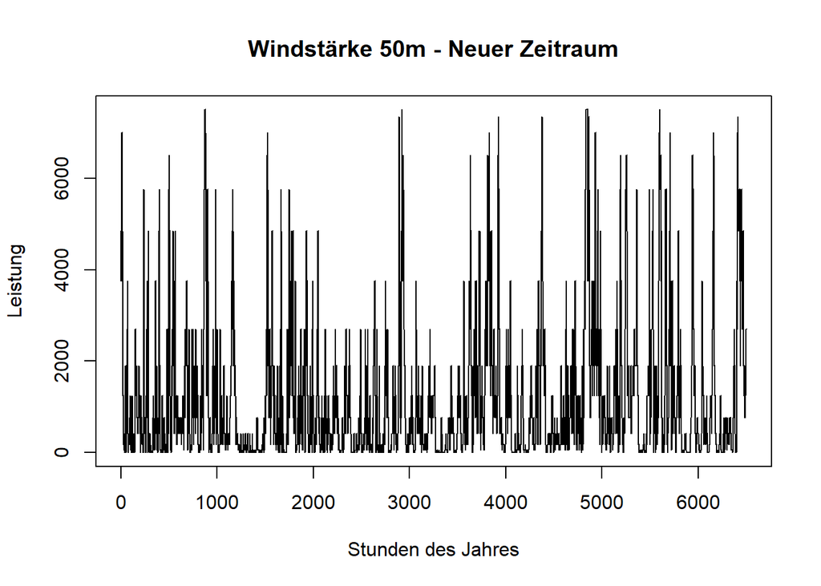

```r
hourly_wind_data_jm = nasapower::get_power(community = "re", pars = c("WS10M", "WS50M"), temporal_api = "HOURLY",
                                        lonlat = c(11.1421496, 48.7716291), dates = c("2009-05-06", "2010-01-31")) # neuer Zeithorizont
# 8760 Std entsprechen einen Jahr => neuer Stundensatz zwischen Mai und Jänner müssen gefunden werden
std_ofyear = diff_days * 24

# wie oben ist der orginale Df ein tribble

hourly_wind_data_jm = data.frame(hourly_wind_data_jm)

#mit einer Enercon E-126 Windkraftwerk berechnet ergibt folgende Leistung:

hourly_wind_energy_jm = calculate_wind_outputs(windspeeds = hourly_wind_data_jm$WS50M, measured_height = 50, hub_height = 135, cutin_speed = 3, cutout_speed = 25, power_curve = pow_curve_df, terrain = "onshore")
plot(hourly_wind_energy_jm, type = 'l', xlab = 'Stunden des Jahres', ylab = 'Leistung', main = "Windstärke 50m - Neuer Zeitraum")
```

```r
capacity_factor_rough_jm = 0.001*sum(hourly_wind_energy_jm)/(7.5*std_ofyear)
```

Wie sehen die Kapazitätsfaktoren jetzt aus?

```
## [1] "NASA-DB Kap. Faktor im Zeitraum Mai - Jänner beträgt: 15.9%"
```

```
## [1] "NASA-DB Kap. Faktor im Jahreszeitraum beträgt: 17.3%"
```

```
## [1] "bReeze Kap. Faktor im Zeitraum Mai - Jänner beträgt: 18.6%"
```

Der Abstand zwischen den Kapazitätsfaktoren wird, wenig überraschend, größer und nicht kleiner.

# 2. Gibt es eine Erklärung für die dargestellten Differenzen?

Vermutung: die Differenz könnte in der unterschiedlichen Berechnung der Outputs liegen.

Das heißt der bReez Datensatz wird mit der Funktion calculate_wind_outputs verschnitten

Dafür muss der Dataframe winddata aufbereitet werden

```r
#Was für ein Format ist date_time
class(winddata$date_time)
```

```
## [1] "character"
```

```r
#Ändere das Format zu datetime :
winddata$date_time = as_datetime(winddata$date_time,format =  "%d.%m.%Y %H")

# Gruppieren zu Stunden Daten
hourly_data = winddata %>% group_by(date_time) %>%
  summarise(Mean_hour=mean(v1_40m_avg),
            .groups = 'drop') %>% as.data.frame()
hourly_wind_energy_jm2 = calculate_wind_outputs(windspeeds = hourly_data$Mean_hour, measured_height = 40, hub_height = 135, cutin_speed = 3, cutout_speed = 25, power_curve = pow_curve_df, terrain = "onshore")
capacity_factor_rough_jm2 = 0.001*sum(hourly_wind_energy_jm2)/(7.5*length(hourly_data$Mean_hour))
```

```
## [1] "bReeze Kap. Faktor berechnet mit der Funktion calculate_wind_outputs beträgt: 13.8%"
```

Die Berechnung zeigt, dass die Differenz des Kap. Faktors noch größer wird. Ein Grund dafür ist wahrscheinlich die Gruppierung auf Stundendaten mit gemittelten Windstärken.

Andererseits kann auch der potenzielle Energieinhalt des Windes in den Datensätzen unterschiedlich sein.

# Überprüfung des Energieinhalt

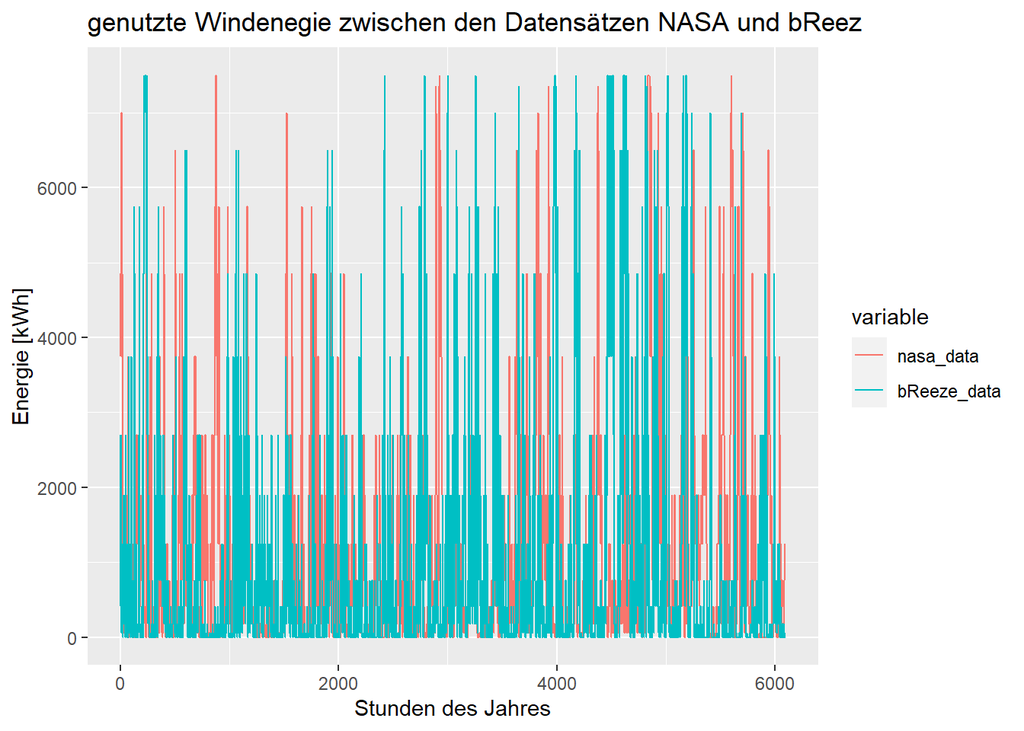

```
## [1] "Die genütze Windenergie im NASA Datensatz beträgt: 7117.485 MWh"
```

```
## [1] "Die genütze Windenergie im bReeze Datensatz beträgt: 6293.61 MWh"
```

```
## [1] "Das bedeutet eine Abweichung von 11.6%"
```

```r
data_line = data.frame(hour = seq(1:6093), nasa_data = hourly_wind_energy_jm[1:6093],bReeze_data = hourly_wind_energy_jm2)
Molten <- melt(data_line, id.vars = "hour")
ggplot(Molten, aes(x = hour, y = value, colour = variable)) + geom_line() +ggtitle("genutzte Windenegie zwischen den Datensätzen NASA und bReez") +
  xlab("Stunden des Jahres") + ylab("Energie [kWh]")
```

Iin Summe weisen die bReeze Daten, berechnet durch die Funktion, 12% weniger genutzen Wind aus. . #Liegt das an einem Umrechnungsfaktor in der Funktion oder an den Windenergiedaten?

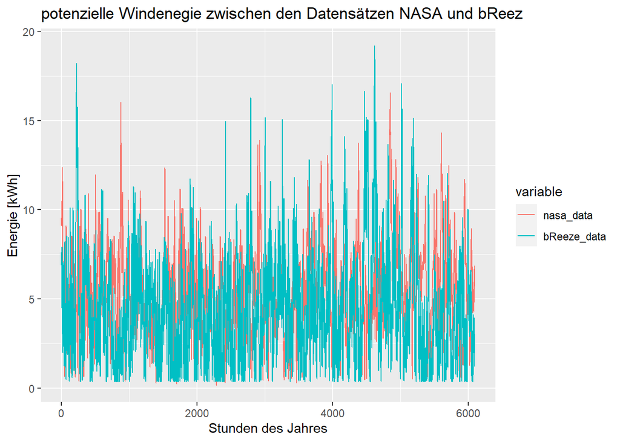

```
##    nasa_data       bReeze_data
##  Min.   : 0.170   Min.   : 0.370
##  1st Qu.: 3.570   1st Qu.: 2.015
##  Median : 5.280   Median : 4.072
##  Mean   : 5.414   Mean   : 4.472
##  3rd Qu.: 7.040   3rd Qu.: 6.223
##  Max.   :16.560   Max.   :19.205
```

```r
data_line_wd = data.frame(hour = seq(1:6093), nasa_data = hourly_wind_data_jm$WS50M[1:6093],bReeze_data = hourly_data$Mean_hour)
Molten <- melt(data_line_wd, id.vars = "hour")
ggplot(Molten, aes(x = hour, y = value, colour = variable)) + geom_line()  +ggtitle("potenzielle Windenegie zwischen den Datensätzen NASA und bReez") +
  xlab("Stunden des Jahres") + ylab("Energie [kWh]")
```

Vermutung: Die NASA Daten sind geglätteter:

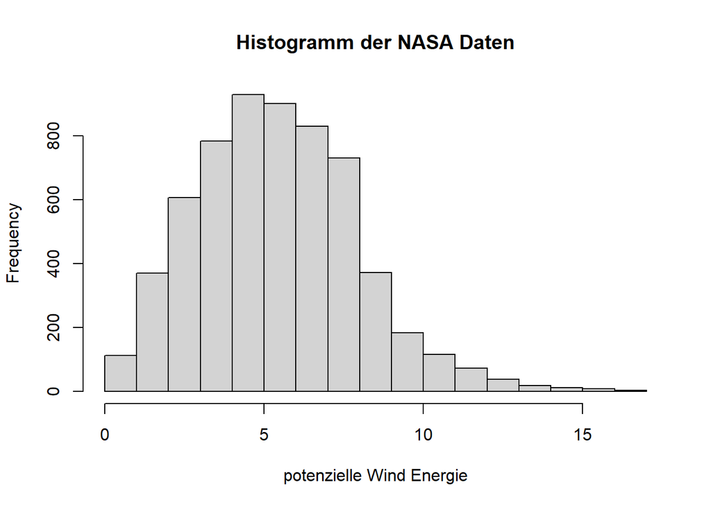

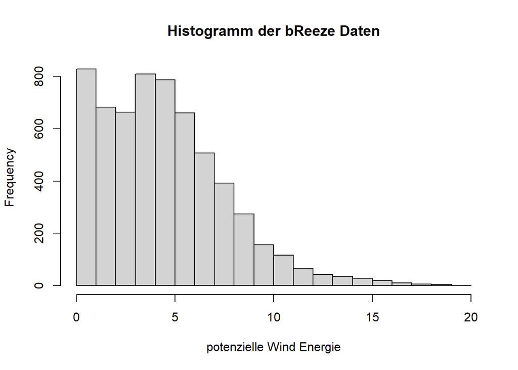

Die NASA Daten könnten normal verteilt sein.

```
## [1] "Die potenzielle Windenergie im NASA Datensatz beträgt: 32.98983 MWh"
```

```
## [1] "Die potenzielle Windenergie im bReeze Datensatz beträgt: 27.2498571666667 MWh"
```

```
## [1] "Das bedeutet eine Abweichung von 17.4%"
```

Der unterschied zwischen den potenziellen Windenergien ist größer als nach der Umrechnung in elektrische Leistung  
Es ist möglich das diese Verschiebung durch die Hellmankonstante, in der Funktion, auftritt

Grundsätzlich ist der Unterschied in den Kap. Faktoren allerdings in den Basis Daten zu finden.